# mining_pisa_data

## Preliminary Wrangling

```python
# import all packages and set plots to be embedded inline
import numpy as np
import pandas as pd
import matplotlib.pyplot as plt
import seaborn as sb

%matplotlib inline
```

#### Interesting columns:

In a first inspection of the dataframe the shape revealed 636 columns. To reduce the complexity in the analysis and speed up the analysis I identified key columns on which I will focus. I mainly focused on the maths grades as well as how homework and the parents influence the scores.

- STIDSTD: Student ID
- ST01Q01: International Grade
- ST03Q01: Birth - Month
- PARED: Highest parental education in years
- OUTHOURS: Out-of-School Study Time
- MISCED: Educational level of mother (ISCED)
- FISCED: Educational level of father (ISCED)
- MTSUP: Mathematics Teacher's Support
- MMINS: Learning time (minutes per week)- Mathematics
- HISCED: Highest educational level of parents
- HEDRES: Home educational resources
- FAILMAT: Attributions to Failure in Mathematics
- AGE: Age of student
- IC09Q06: Out-of-school 9 - Homework
- ST89Q04: Attitude toward School - Enjoy Good Grades
- ST89Q03: Attitude toward School - Prepare for College
- ST89Q05: Attitude toward School - Trying Hard is Important
- ST88Q04: Attitude towards School - Useful for Job
- ST88Q03: Attitude towards School - Gave Me Confidence
- ST88Q02: Attitude towards School - Waste of Time
- ST88Q01: Attitude towards School - Does Little to Prepare Me for Life
- ST70Q02: No of class period p/wk - Maths
- ST69Q02: Min in class period - Maths
- ST57Q01: Out-of-School Study Time - Homework
- ST57Q05: Out-of-School Study Time - With Parent
- ST57Q02: Out-of-School Study Time - Guided Homework
- ST57Q04: Out-of-School Study Time - Commercial Company
- ST57Q03: Out-of-School Study Time - Personal Tutor
- ST35Q04: Subjective Norms - Parents Believe Studying Mathematics Is Important
- ST35Q05: Subjective Norms - Parents Believe Mathematics Is Important for Career
- ST35Q06: Subjective Norms - Parents Like Mathematics
- PV1MATH: Plausible value 1 in mathematics
- PV2MATH: Plausible value 2 in mathematics
- PV3MATH: Plausible value 3 in mathematics
- PV4MATH: Plausible value 4 in mathematics
- PV5MATH: Plausible value 5 in mathematics

```python
cols_of_interest = ["CNT",
"NC",
"STIDSTD",
"ST01Q01",
"ST03Q01",
"PARED",
"OUTHOURS",
"MISCED",
"FISCED",
"MTSUP",
"MMINS",
"HISCED",
"HEDRES",
"FAILMAT",
"AGE",
"IC09Q06",

"ST89Q03", #Attitude toward school
"ST89Q04",
"ST89Q05",
"ST88Q04",
"ST88Q03",
"ST88Q02",
"ST88Q01",

"ST70Q02",
"ST69Q02",

"ST57Q05", # out of school study time
"ST57Q01",
"ST57Q02",
"ST57Q03",
"ST57Q04",
"ST35Q04",
"ST35Q05",
"ST35Q06",

"PV1MATH", # Math test scores
"PV2MATH",
"PV3MATH",
"PV4MATH",
"PV5MATH"]
```

```python
#df = pd.read_csv("pisa2012.csv", encoding = "latin-1", dtype='unicode', index_col = False)
df = pd.read_csv("pisa2012.csv", encoding = "latin-1", dtype='unicode', index_col = False, usecols = cols_of_interest)
```

```python
df.head(1)
```

|  | CNT | NC | STIDSTD | ST01Q01 | ST03Q01 | ST35Q04 | ST35Q05 | ST35Q06 | ST57Q01 | ST57Q02 | ... | MISCED | MMINS | MTSUP | OUTHOURS | PARED | PV1MATH | PV2MATH | PV3MATH | PV4MATH | PV5MATH |
| --- | --- | --- | --- | --- | --- | --- | --- | --- | --- | --- | --- | --- | --- | --- | --- | --- | --- | --- | --- | --- | --- |
| 0 | Albania | Albania | 00001 | 10 | 02 | Agree | Agree | Agree | NaN | NaN | ... | ISCED 3A, ISCED 4 | NaN | -0.9508 | NaN | 12 | 406.8469 | 376.4683 | 344.5319 | 321.1637 | 381.9209 |

1 rows × 38 columns

```python
df.shape
```

```
(485490, 38)
```

```python
df.info()
```

```
<class 'pandas.core.frame.DataFrame'>
RangeIndex: 485490 entries, 0 to 485489
Data columns (total 38 columns):
CNT         485490 non-null object
NC          485490 non-null object
STIDSTD     485490 non-null object
ST01Q01     485490 non-null object
ST03Q01     485490 non-null object
ST35Q04     315160 non-null object
ST35Q05     314843 non-null object
ST35Q06     313389 non-null object
ST57Q01     301367 non-null object
ST57Q02     269808 non-null object
ST57Q03     283813 non-null object
ST57Q04     279657 non-null object
ST57Q05     289502 non-null object
ST69Q02     298601 non-null object
ST70Q02     298339 non-null object
ST88Q01     311250 non-null object
ST88Q02     310964 non-null object
ST88Q03     310980 non-null object
ST88Q04     311371 non-null object
ST89Q03     311233 non-null object
ST89Q04     311243 non-null object
ST89Q05     311138 non-null object
IC09Q06     291982 non-null object
AGE         485374 non-null object
FAILMAT     314448 non-null object
FISCED      452903 non-null object
HEDRES      477772 non-null object
HISCED      473091 non-null object
MISCED      467085 non-null object
MMINS       283303 non-null object
MTSUP       313599 non-null object
OUTHOURS    308799 non-null object
PARED       473091 non-null object
PV1MATH     485490 non-null object
PV2MATH     485490 non-null object
PV3MATH     485490 non-null object
PV4MATH     485490 non-null object
PV5MATH     485490 non-null object
dtypes: object(38)
memory usage: 140.8+ MB
```

All columns are strings. While this makes sense for some, others should be floats.

```python
df.ST88Q04.value_counts()
```

```
Agree                153181
Strongly agree       124825
Disagree              24735
Strongly disagree      8630
Name: ST88Q04, dtype: int64
```

```python
print(df.ST88Q04[2])
print(df.ST88Q02[1])
print(df.ST88Q03[1])
print(df.ST88Q01[1])
```

```
nan
nan
nan
nan
```

```python
# convert the attitude towwards school columns into ordered categorical types
attitude_cols = ["ST89Q03", "ST89Q04",
"ST89Q05","ST88Q04","ST88Q03","ST88Q02","ST88Q01"]
order = ["Strongly disagree", "Disagree", "Agree", "Strongly agree"]
ordered_var = pd.api.types.CategoricalDtype(ordered = True, categories = order)
for col in attitude_cols:
    df[col] = df[col].astype(ordered_var)
```

```python
# Prepares education level of parents to be transformed to ordinal data
df.FISCED.replace(to_replace = ["ISCED 3B C","ISCED 3A, ISCED 4" ], value= "ISCED 3 & 4",inplace = True)
df.MISCED.replace(to_replace = ["ISCED 3B C","ISCED 3A, ISCED 4" ], value= "ISCED 3 & 4",inplace = True)
```

```python
df.FISCED.value_counts()
```

```
ISCED 3 & 4    118890
ISCED 5A, 6    113406
ISCED 2         66728
ISCED 5B        61617
ISCED 3B, C     39789
ISCED 1         35938
None            16535
Name: FISCED, dtype: int64
```

```python
ed_order = ["None", "ISCED 1","ISCED 2","ISCED 3B, C", "ISCED 3 & 4", "ISCED 5B", "ISCED 5A, 6" ]
ordered_var = pd.api.types.CategoricalDtype(ordered = True, categories = ed_order)

ed_cols = ["FISCED", "MISCED"]
for col in ed_cols:
    df[col] = df[col].astype(ordered_var)
```

```python
float_cols = ["PV1MATH",
"PV2MATH",
"PV3MATH",
"PV4MATH",
"PV5MATH",
"AGE",
"ST01Q01",
"PARED",
"MMINS",
"OUTHOURS",
"MTSUP"]
# Converting the numerical columns into floats
for col in float_cols:
    df[col] = df[col].astype(float)
```

```python
df.PV5MATH[0]
```

```
381.9209
```

```python
# Some column names are very non-descript and are changed:
names = {"PV1MATH": "MathResult1","PV2MATH": "MathResult2","PV3MATH": "MathResult3",
         "PV4MATH": "MathResult4","PV5MATH": "MathResult5","MISCED": "ed_lvl_mum",
         "FISCED": "ed_lvl_dad"
        }
df.rename(columns = names, inplace = True)
```

```python
df.info()
```

```
<class 'pandas.core.frame.DataFrame'>
RangeIndex: 485490 entries, 0 to 485489
Data columns (total 38 columns):
CNT            485490 non-null object
NC             485490 non-null object
STIDSTD        485490 non-null object
ST01Q01        485490 non-null float64
ST03Q01        485490 non-null object
ST35Q04        315160 non-null object
ST35Q05        314843 non-null object
ST35Q06        313389 non-null object
ST57Q01        301367 non-null object
ST57Q02        269808 non-null object
ST57Q03        283813 non-null object
ST57Q04        279657 non-null object
ST57Q05        289502 non-null object
ST69Q02        298601 non-null object
ST70Q02        298339 non-null object
ST88Q01        311250 non-null category
ST88Q02        310964 non-null category
ST88Q03        310980 non-null category
ST88Q04        311371 non-null category
ST89Q03        311233 non-null category
ST89Q04        311243 non-null category
ST89Q05        311138 non-null category
IC09Q06        291982 non-null object
AGE            485374 non-null float64
FAILMAT        314448 non-null object
ed_lvl_dad     452903 non-null category
HEDRES         477772 non-null object
HISCED         473091 non-null object
ed_lvl_mum     467085 non-null category
MMINS          283303 non-null float64
MTSUP          313599 non-null float64
OUTHOURS       308799 non-null float64
PARED          473091 non-null float64
MathResult1    485490 non-null float64
MathResult2    485490 non-null float64
MathResult3    485490 non-null float64
MathResult4    485490 non-null float64
MathResult5    485490 non-null float64
dtypes: category(9), float64(11), object(18)
memory usage: 111.6+ MB
```

```python
df.NC.nunique()
```

```
66
```

### Structure of data:

The table has data entries for 485490 students of 66 countries. It has numerical values for example for the test scores as well as ordinal categorical values like the attitude towards school.

### Main dataset features:

The main dataset features are the grades which are the outcomes of most or all other columns.

### What features in the dataset do you think will help support your investigation into your feature(s) of interest?

Because the original dataset has over 600 columns, I reduced it to the columns with general inforamtion like age and country aswell as more specific columns related to the parents and situation at home of the student.

## Univariate Exploration

OUTHOURS describes the hours a student works outside of school. The histogram is heavily skewed to the right with a maximum score of 180. 180 hours per week would mean 25.7 hours of work outside of scool per day, which is not possible.

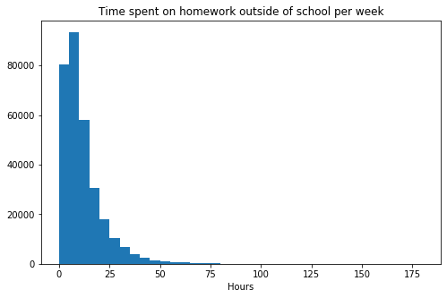

```python
binsize = 5
bins = np.arange(0, df['OUTHOURS'].max()+binsize, binsize)

plt.figure(figsize=[8, 5])
plt.hist(data = df, x = 'OUTHOURS', bins = bins)
plt.xlabel('Hours');
plt.title("Time spent on homework outside of school per week")
```

```python
df.OUTHOURS.describe()
```

```
count    308799.000000
mean         11.104100
std          10.476669
min           0.000000
25%           4.000000
50%           8.000000
75%          14.000000
max         180.000000
Name: OUTHOURS, dtype: float64
```

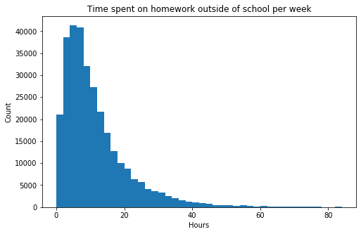

```python
# With 16 waking hours 12 hours per day is set as the absolute maximum possible amount of time.

binsize = 2
bins = np.arange(0, 7*12+binsize, binsize)

plt.figure(figsize=[8, 5])
plt.hist(data = df, x = 'OUTHOURS', bins = bins)
plt.xlabel('Hours')
plt.ylabel("Count")
plt.title("Time spent on homework outside of school per week");
```

There is a peak aroung 8 hours of extra work outside of school per week with a few students working much more.

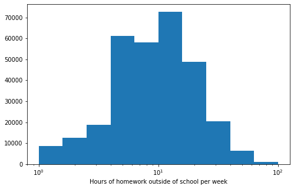

```python
# there's a long tail in the distribution, so let's put it on a log scale instead
df_adj = df.copy()
# there are a lot of 0 values which are difficult to deal with in a log transformation so we add 0.01 hours for every student
df_adj.OUTHOURS += 1
df_adj.OUTHOURS.dropna(inplace = True)


binsize = 2
bins = np.arange(0, 7*12+binsize, binsize)

log_binsize = 0.2
bins = 10 ** np.arange(0, np.log10(84)+log_binsize, log_binsize)

plt.figure(figsize=[8, 5])
plt.hist(data = df_adj, x = 'OUTHOURS', bins = bins)
plt.xscale("log")
plt.xlabel('Hours of homework outside of school per week');
```

The logscale of the x-axis revealed a univarete distribution after the transformation. There were no hidden second peaks.

It would be interesting to see how amount of work outside of school and grades compare. Therefore the test scores are investigated next.

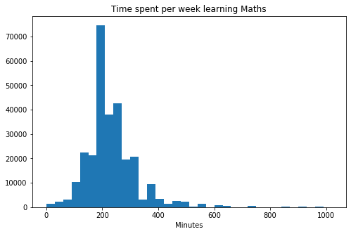

```python
binsize = 30
bins = np.arange(0, 1000+binsize, binsize)

plt.figure(figsize=[8, 5])
plt.hist(data = df, x = 'MMINS', bins = bins)
plt.xlabel('Minutes')
plt.title("Time spent per week learning Maths");
```

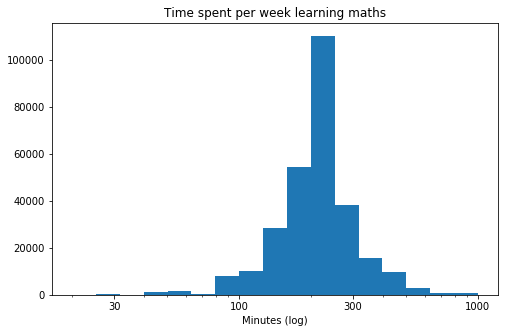

```python
# there's a long tail in the distribution, so let's put it on a log scale instead
df_adj = df.copy()
# there are a lot of 0 values which are difficult to deal with in a log transformation so we add 0.01 hours for every student
df_adj.MMINS += 1
df_adj.MMINS.dropna(inplace = True)



log_binsize = 0.1
bins = 10 ** np.arange(np.log10(20), np.log10(1000)+log_binsize, log_binsize)

plt.figure(figsize=[8, 5])
plt.hist(data = df_adj, x = 'MMINS', bins = bins)
plt.xscale("log")
plt.xlabel('Minutes (log)')
xticks = [30, 100, 300, 1000]
plt.xticks(xticks, xticks)
plt.title("Time spent per week learning maths");
```

```python
# To compare the scores a percentage of all 5 results compared to the best results in each column is calculated
df["MathResultSum"] = (df.MathResult1 + df.MathResult2 + df.MathResult3 + df.MathResult4 + df.MathResult5)

df["MathResultPerc"] = (df["MathResultSum"]/(df.MathResult1.max() + df.MathResult2.max() + df.MathResult3.max() + df.MathResult4.max() + df.MathResult5.max()))*100
```

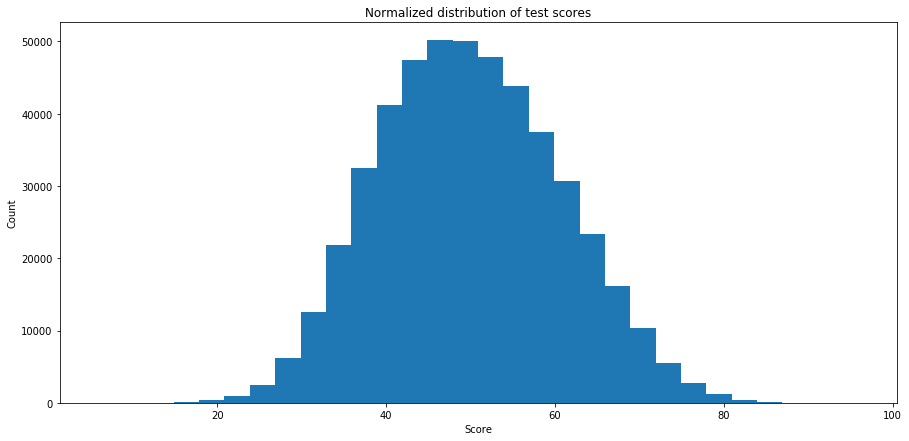

```python
plt.figure(figsize = (15,7))
plt.hist(x = "MathResultPerc", data = df, bins = 30)
plt.xlabel("Score")
plt.ylabel("Count")
plt.title("Normalized distribution of test scores");
```

The test scores are according to a normal distribution. Interesting, since the time spent outside of school doing homework is not normally distributed. Lets have a look at the attitude towards school next:

First: Trying hard is important.

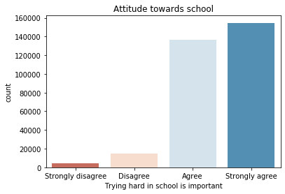

```python
sb.countplot(x = "ST89Q05", data = df, palette = sb.color_palette("RdBu", 4))
plt.xlabel("Trying hard in school is important")
plt.title("Attitude towards school");
```

Most students think trying hard in school is important which is great!

Next: School is a waste of time.

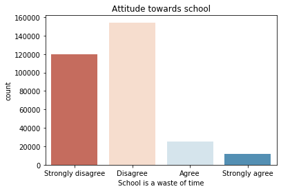

```python
sb.countplot(x = "ST88Q02", data = df, palette = sb.color_palette("RdBu", 4))
plt.xlabel("School is a waste of time")
plt.title("Attitude towards school");
```

The plot seems to agree that school is considered good and important for most children.

Lets have a last look at the education level of the parents:

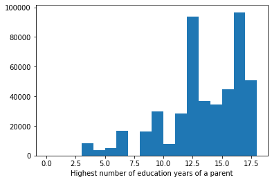

```python
bins = np.arange(0, df.PARED.max()+1, 1)
plt.hist(data = df, x = "PARED", bins = bins)
plt.xlabel("Highest number of education years of a parent");
```

With the peaks at 12.5 years (full high school education) of education and 17 years of education (Masters degree) most families have at least one parent which has a good education.

To see the effect the education level of father and mother has the distribution is plottet aswell.

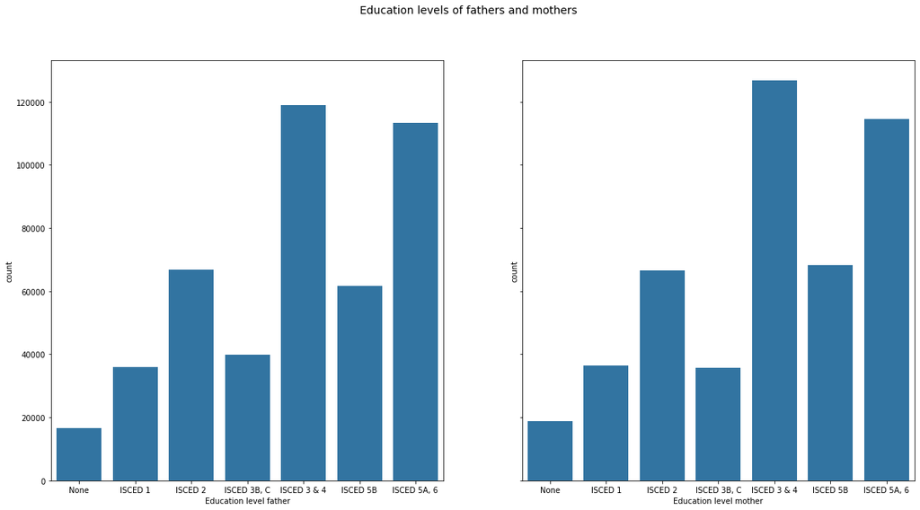

```python
base_color = sb.color_palette()[0]
fig, ax =plt.subplots(nrows = 1, ncols = 2, sharey = True, figsize= (20,10))
sb.countplot( x = "ed_lvl_dad", data = df, color = base_color, ax=ax[0])
sb.countplot( x = "ed_lvl_mum", data = df, color = base_color , ax=ax[1])
ax[0].set(xlabel = "Education level father")
ax[1].set(xlabel = "Education level mother")
plt.suptitle("Education levels of fathers and mothers", fontsize = 14);
```

### Discuss the distribution(s) of your variable(s) of interest. Were there any unusual points? Did you need to perform any transformations?

A transformation for the hours of schoolwork outside of school was necessary since it was heavily skewed to the right. However the transformation did not reveal additional insight. I also transformed the test results to make the easily comparable as a percentage. They are now relative to the highest score achieved in each test.

### Of the features you investigated, were there any unusual distributions? Did you perform any operations on the data to tidy, adjust, or change the form of the data? If so, why did you do this?

There are some ordinal categorical variables which needed to be ordered as they were saved as strings. I consolidated the ISCED level a bit to make the levels easier to compare.

## Bivariate Exploration

Lets start of by looking into the relationship between hours of work outside of school and the achieved score:

```python
# Filtering out all values above 7*12=84
da = df.query('OUTHOURS < 84')
db = df.query('MMINS < 1500')
```

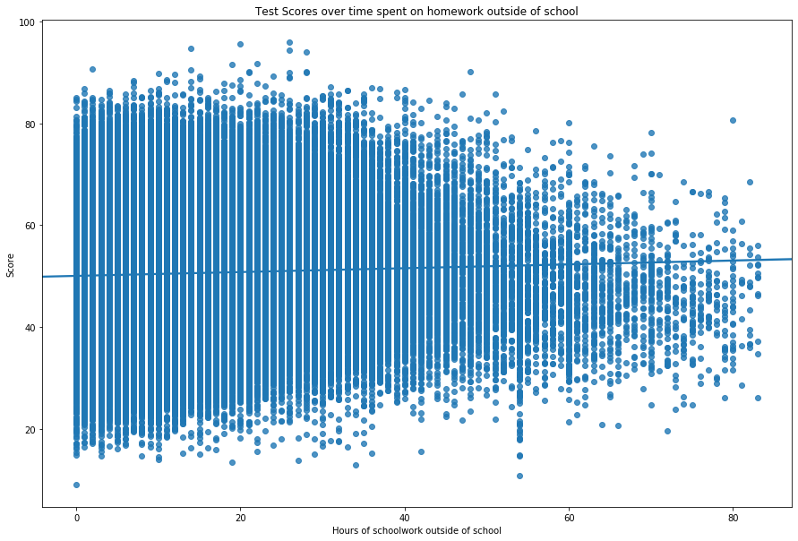

```python
plt.figure(figsize = (15,10))
g = sb.regplot(x = "OUTHOURS", y ="MathResultPerc", data = da)
g.set(xlabel='Hours of schoolwork outside of school', ylabel='Score')
plt.title("Test Scores over time spent on homework outside of school");
```

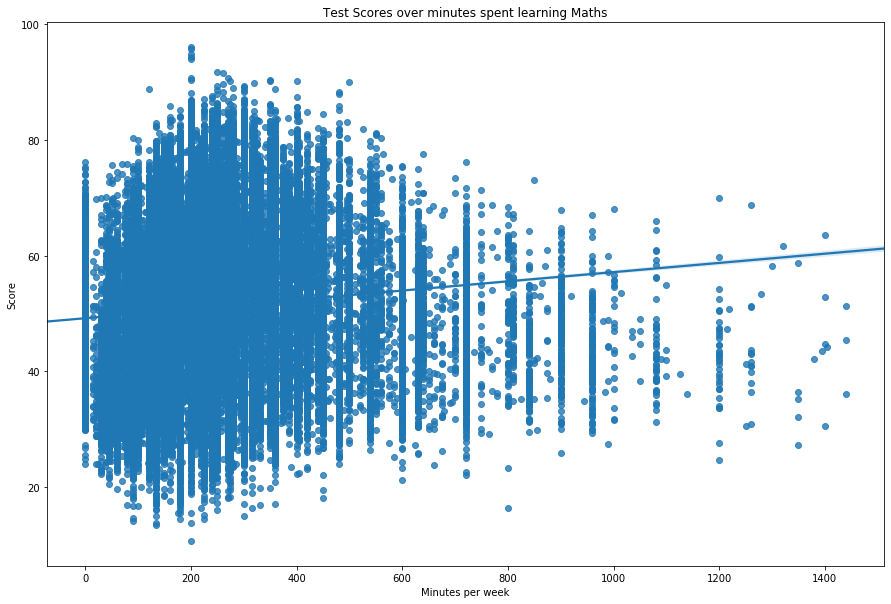

```python
plt.figure(figsize = (15,10))
g = sb.regplot(x = "MMINS", y ="MathResultPerc", data = db)
g.set(xlabel='Minutes per week', ylabel='Score')
plt.title("Test Scores over minutes spent learning Maths");
```

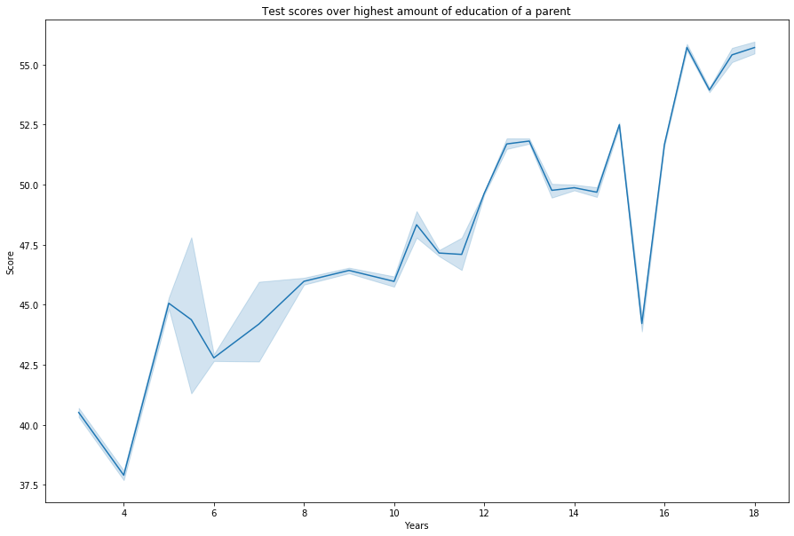

```python
plt.figure(figsize = (15,10))
g = sb.lineplot(x = "PARED", y ="MathResultPerc", data = df)
g.set(xlabel='Years', ylabel='Score')
plt.title("Test scores over highest amount of education of a parent");
```

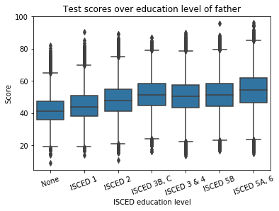

```python
g = sb.boxplot(x = "ed_lvl_dad", y = "MathResultPerc", data = da, color = base_color)
g.set(xlabel='ISCED education level', ylabel='Score')
plt.title("Test scores over education level of father")
plt.xticks(rotation = 20);
```

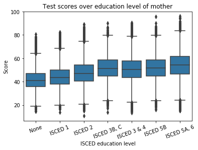

```python
g = sb.boxplot(x = "ed_lvl_mum", y = "MathResultPerc", data = da, color = base_color)
g.set(xlabel='ISCED education level', ylabel='Score')
plt.title("Test scores over education level of mother")
plt.xticks(rotation = 20);
```

### Did you observe any interesting relationships between the other features (not the main feature(s) of interest)?

The education background of the parents and number of years they themselves were educated seems to have a significant impact on the test scores of the children.

## Multivariate Exploration

```python
# Draw a Heatmap

def hist2dgrid(x, y, **kwargs):
    palette = kwargs.pop('color')
    bins_x = np.arange(0, 1400+50, 50)
    bins_y = np.arange(0, 100, 5)
    plt.hist2d(x, y, bins = [bins_x, bins_y], cmap = palette, cmin = 0.5)
```

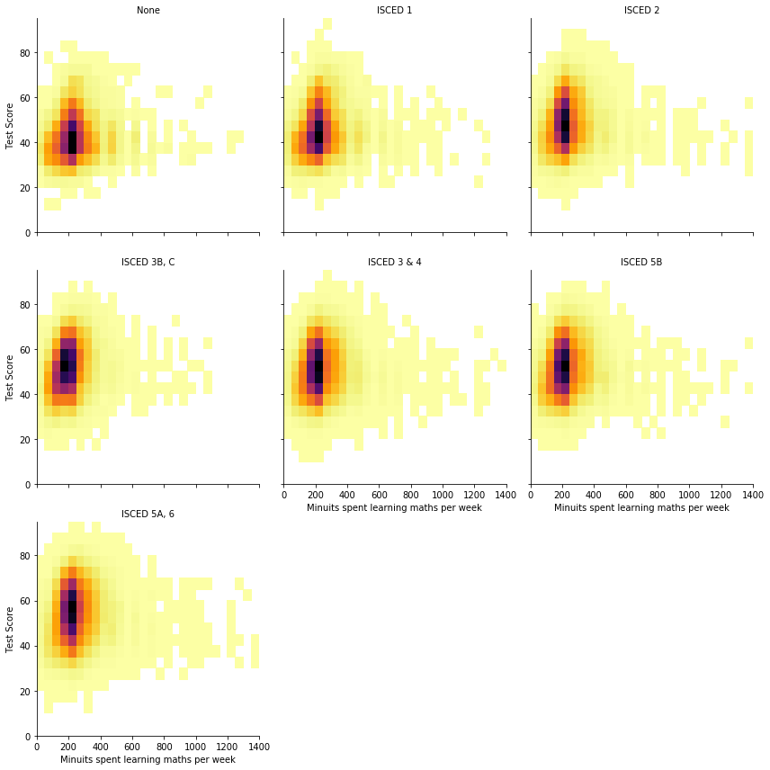

```python
# create faceted heat maps on levels of the education level variable
g = sb.FacetGrid(data = df, col = 'ed_lvl_dad', col_wrap = 3, height = 4)
g.map(hist2dgrid, 'MMINS', "MathResultPerc", color = 'inferno_r')
g.set_xlabels('Minuits spent learning maths per week')
g.set_ylabels('Test Score')
g.set_titles("{col_name}");
```

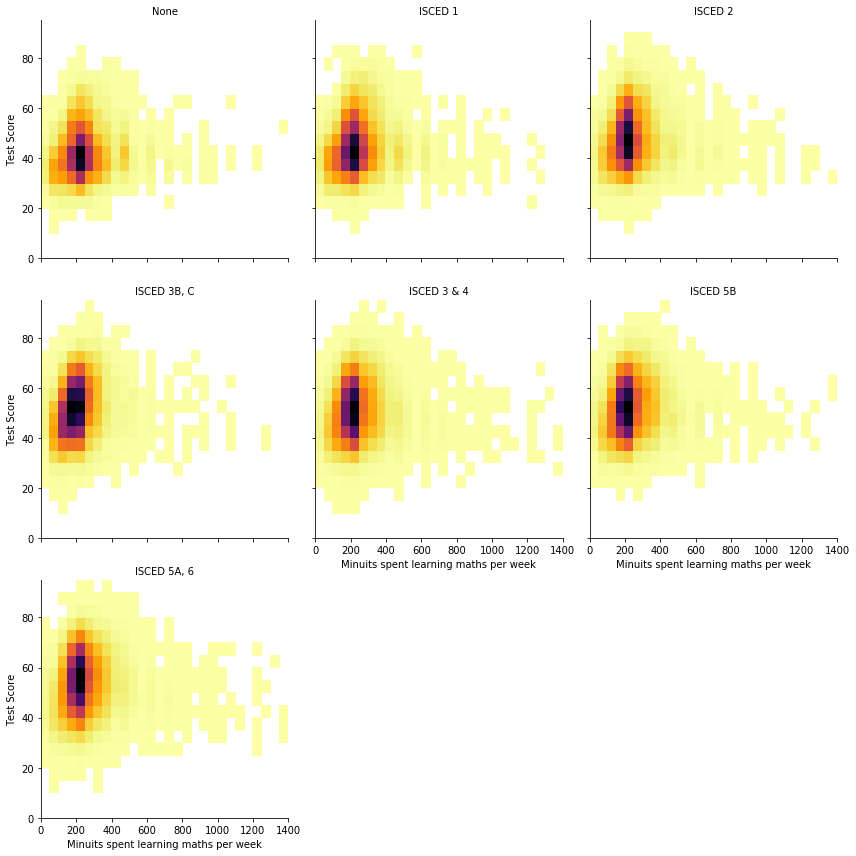

```python
# create faceted heat maps on levels of the education level variable
g = sb.FacetGrid(data = df, col = 'ed_lvl_mum', col_wrap = 3, height = 4)
g.map(hist2dgrid, 'MMINS', "MathResultPerc", color = 'inferno_r')
g.set_xlabels('Minuits spent learning maths per week')
g.set_ylabels('Test Score')
g.set_titles("{col_name}");
```

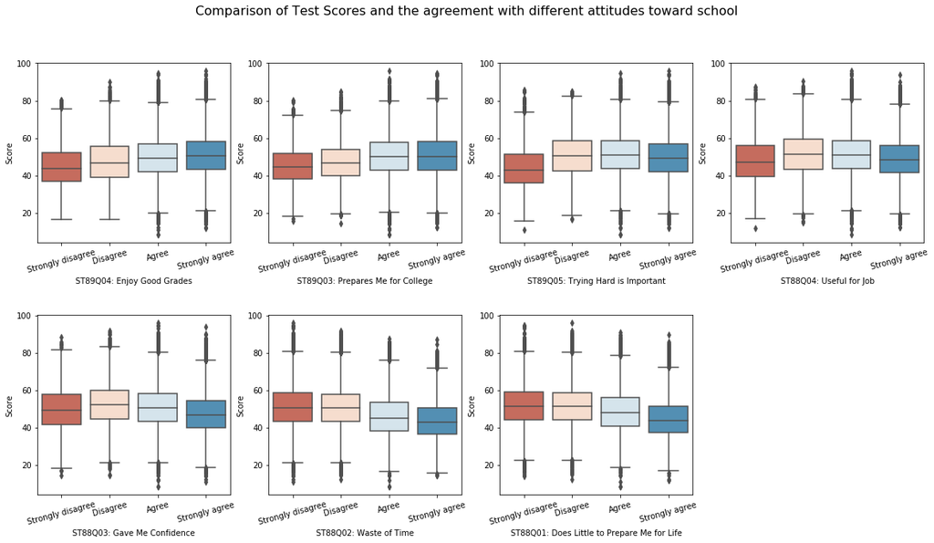

```python
attitude_cols = ["ST89Q04","ST89Q03","ST89Q05","ST88Q04","ST88Q03","ST88Q02", "ST88Q01"]
labels = ["ST89Q04: Enjoy Good Grades",
"ST89Q03: Prepares Me for College",
"ST89Q05: Trying Hard is Important",
"ST88Q04: Useful for Job",
"ST88Q03: Gave Me Confidence",
"ST88Q02: Waste of Time",
"ST88Q01: Does Little to Prepare Me for Life"]

# Draw boxplots for each attitude towards school
fig = plt.figure(figsize = (20,10))
for i in range(1, len(attitude_cols)+1):
    ax = fig.add_subplot(2, 4, i)
    sb.boxplot(x = attitude_cols[i-1],y = "MathResultPerc", data = df, ax = ax, palette = sb.color_palette("RdBu", 4))
    ax.set(xlabel = labels[i-1])
    plt.xticks(rotation = 15)
    ax.set(ylabel = "Score")
plt.subplots_adjust(hspace=0.4)
fig.suptitle("Comparison of Test Scores and the agreement with different attitudes toward school", fontsize = 16);
```

### Were there any interesting or surprising interactions between features?

The heatmap of test scores, minuits studied and education level of the parent has a couple interesting insights. First, the students with the highest scores are all within the first third of study time. Second when students study a lot the minimum scores rise so studying a lot more does help to increase the score. However the max scores decreases the more student studies which suggests that there is a limit in terms of score a student can achieve no matter how much he studies. Third the higher the education level of the parents the more students are present studying a lot (more than 600 min per week).